# Load packages

# Violin plots behave very similarly to boxplots

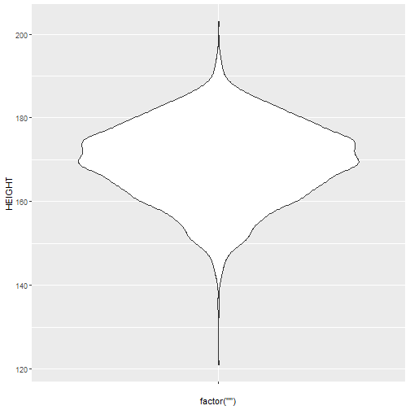

```r
ggplot(data=demog.data, aes(x=factor(""), y=HEIGHT)) + geom_violin()
```

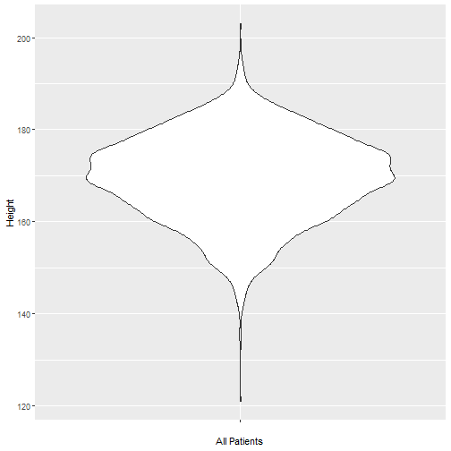

```r
ggplot(data=demog.data, aes(x=factor(""), y=HEIGHT)) + geom_violin() + labs(x="All Patients", y="Height")
```

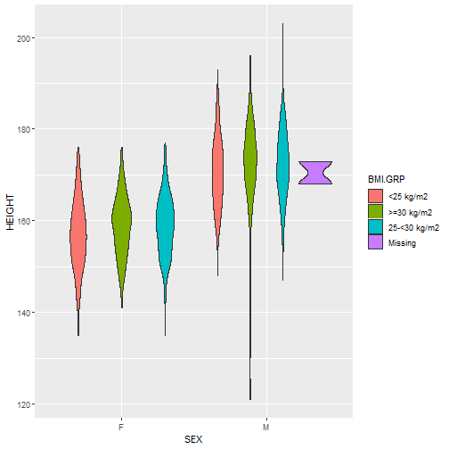

```r
ggplot(data=demog.data, aes(x=SEX, y=HEIGHT, fill=BMI.GRP)) + geom_violin()
```

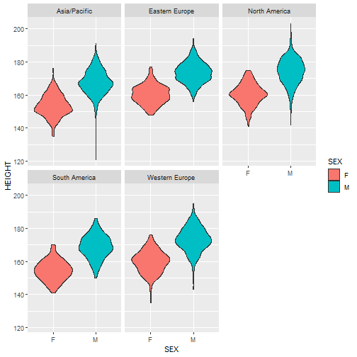

```r
ggplot(data=demog.data, aes(x=SEX, y=HEIGHT, fill=SEX)) + geom_violin() + facet_wrap(~REGION)
```

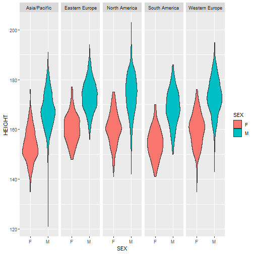

```r
ggplot(data=demog.data, aes(x=SEX, y=HEIGHT, fill=SEX)) + geom_violin() + facet_wrap(~REGION, nrow=1)
```

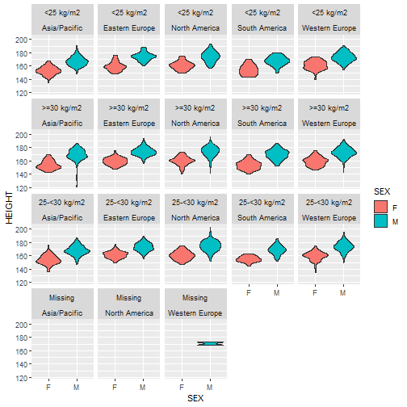

```r
ggplot(data=demog.data, aes(x=SEX, y=HEIGHT, fill=SEX)) + geom_violin() + facet_wrap(BMI.GRP~REGION)
```

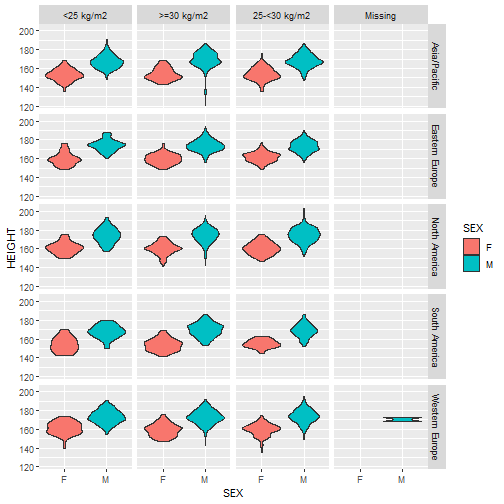

```r
ggplot(data=demog.data, aes(x=SEX, y=HEIGHT, fill=SEX)) + geom_violin() + facet_grid(REGION~BMI.GRP)
```

## Problems: need to reorder levels of BMI.GRP

- Need to suppress the missing group
- Need to move the legend to make better use of real estate
- This chunk of code is to get the superscripts into labels

```r
# First get rid of missing category
demog.data2 <- subset(demog.data, BMI.GRP != "Missing")
levels(demog.data$BMI.GRP)
# Problem 1 - levels are out of order
demog.data2$BMI.GRP <- factor(demog.data2$BMI.GRP, c("<25 kg/m2", "25-<30 kg/m2", ">=30 kg/m2" , "Missing"))
levels(demog.data2$BMI.GRP)
# Better
ggplot(data=demog.data2, aes(x=SEX, y=HEIGHT, fill=SEX)) + geom_violin() + facet_grid(REGION~BMI.GRP)
# Punching it up; Note use of escape character '\n' for new line.
p <- ggplot(data=demog.data2, aes(x=SEX, y=HEIGHT, fill=SEX)) + geom_violin() + facet_grid(REGION~BMI.GRP)+
  theme(legend.position="none", strip.text=element_text(size=13)) + labs(x="Gender", y="Height", title="Violin plots of Height by Gender\nfor each BMI Group and Region")
p

demog.data2$BMI.GRP2 <- demog.data2$BMI.GRP
levels(demog.data2$BMI.GRP2) <- c(TeX(paste0("<25 kg/", "$m^2$")),
                                 TeX(paste0("25-<30 kg/", "$m^2$")),
                                 TeX(paste0("<25 kg/", "$m^2$")),
                                 TeX(paste0("$\\leq 30$", "kg/", "$m^2$")))
t1 <- expression(paste("Asia & Pacific"))
t2 <- expression(paste("Eastern Europe"))
t3 <- expression(paste("North America"))
t4 <- expression(paste("South America"))
t5 <- expression(paste("Western Europe"))
demog.data2$REGION2 <- factor(demog.data2$REGION, levels =levels(demog.data2$REGION), labels=c(t1, t2, t3, t4, t5) )

# note that Region does not throw an error here
ggplot(data=demog.data2, aes(x=SEX, y=HEIGHT, fill=SEX)) + geom_violin() + facet_grid(REGION~BMI.GRP2)+
  theme(legend.position="none", strip.text=element_text(size=13)) + labs(x="Gender", y="Height", title="Violin plots of Height by Gender\nfor each BMI Group and Region")

# note that Region throws an error here
ggplot(data=demog.data2, aes(x=SEX, y=HEIGHT, fill=SEX)) + geom_violin() + facet_grid(REGION~BMI.GRP2, labeller = label_parsed)+
  theme(legend.position="none", strip.text=element_text(size=13)) + labs(x="Gender", y="Height", title="Violin plots of Height by Gender\nfor each BMI Group and Region")
```

```r
# A little more work to get symbols - this is just to whet your appetite
# Redefining factor with 3 levels.  These are expressions that allow superscripts.
# look at help files for phantom - it will introduce you to displaying mathematical expressions
#
temp1 <- expression(paste(phantom()<=25," kg/",m^2))
temp2 <- expression(paste("25-<30 kg/", m^2))
temp3 <- expression(paste(phantom() >= 30, " kg/", m^2))
demog.data2$BMI.GRP2 <- factor(demog.data2$BMI.GRP, levels=c("<25 kg/m2", "25-<30 kg/m2", ">=30 kg/m2"),labels=c(temp1, temp2, temp3))
```

# Unfortunately this step is required since 'label_parsed' is being used in the facet_grid command below

```r
t1 <- expression(paste("Asia/ Pacific"))
t2 <- expression(paste("Eastern Europe"))
t3 <- expression(paste("North America"))
t4 <- expression(paste("South America"))
t5 <- expression(paste("Western Europe"))
```

# So REGION2 makes use of levels and labels,

```r
demog.data2$REGION2 <- factor(demog.data2$REGION, levels =levels(demog.data2$REGION), labels=c(t1, t2, t3, t4, t5) )

d <- ggplot(data=demog.data2, aes(x=SEX, y=HEIGHT, fill=SEX)) +
  geom_violin() +
  facet_grid(REGION2~BMI.GRP2,labeller="label_parsed")+
  labs(x="Gender", y="Height", title=expression(paste("Gender vs. Height by Region and BMI Group" )))+
  theme(legend.position="none", strip.text=element_text(size=13)) +
  labs(x="Gender", y="Height", title="Violin plots of Height by Gender\nfor each BMI Group and Region")

d
```

# Again, geom_violin and geom_boxplot are interchangable

```r
ggplot(data=demog.data2, aes(x=SEX, y=HEIGHT, fill=SEX)) +
  geom_boxplot() +
  facet_grid(REGION2~BMI.GRP2,labeller="label_parsed")+
  labs(x="Gender", y="Height", title=expression(paste("Gender vs. Height by Region and BMI Group" )))+
  theme(legend.position="none", strip.text=element_text(size=13)) + labs(x="Gender", y="Height", title="Violin plots of Height by Gender\nfor each BMI Group and Region")
```

# Now many of the ideas we've seen will carry over to geom_density

```r
ggplot(data=demog.data2, aes(x=HEIGHT, fill=SEX))+geom_density()
# Now transparency really means something
ggplot(data=demog.data2, aes(x=HEIGHT, fill=SEX))+geom_density(alpha=.3)

ggplot(data=demog.data2, aes(x=HEIGHT, fill=SEX))+geom_density(alpha=.3)+facet_wrap(~REGION)
ggplot(data=demog.data2, aes(x=HEIGHT, fill=SEX))+geom_density(alpha=.3)+facet_wrap(~REGION, nrow=1) + theme(legend.position="bottom")
# Making use of the work we did earlier for superscripts
ggplot(data=demog.data2, aes(x=HEIGHT, fill=SEX))+geom_density(alpha=.3)+facet_grid(BMI.GRP2~REGION2, label=label_parsed) + theme(legend.position="bottom")
```

# Continuous vs. continuous

```r
# explore csv file
head(demog.data)

# build table for REGION - a variable holding info on Region
table(demog.data$REGION)
```

```r
# Let's grab a sample
useme <- sample(x=1:nrow(demog.data), size=300)
demog.data2 <- demog.data[useme,]
# Overplotting obscures
ggplot(data=demog.data2, aes(x=REGION, y= HEIGHT)) + geom_violin() + geom_point()
# Jittering helps to see the spread
ggplot(data=demog.data2, aes(x=REGION, HEIGHT, colour=REGION)) + geom_violin() + geom_point(position="jitter")
# Violin and boxplot are interchangable
ggplot(data=demog.data2, aes(x=REGION, HEIGHT)) + geom_boxplot() + geom_point(position="jitter")
```

# Let's look at everything

```r
ggplot(data=demog.data, aes(x=HEIGHT, y=WEIGHT)) + geom_point()
# Jittering is also helpful with scatterplots
ggplot(data=demog.data, aes(x=HEIGHT, y=WEIGHT)) + geom_point(position="jitter")
# Transparency helps
ggplot(data=demog.data, aes(x=HEIGHT, y=WEIGHT)) + geom_point(position="jitter", alpha=.2)

# Back to the smaller set to see color
ggplot(data=demog.data2, aes(x=HEIGHT, y=WEIGHT, color=REGION)) + geom_point()
# Shape mapped to SEX
ggplot(data=demog.data2, aes(x=HEIGHT, y=WEIGHT, color=REGION, shape=SEX)) + geom_point()
# Let's increase the size
ggplot(data=demog.data2, aes(x=HEIGHT, y=WEIGHT, color=REGION, shape=SEX)) + geom_point(size=3)

# We can map size to a factor
ggplot(data=demog.data2, aes(x=HEIGHT, y=WEIGHT, color=REGION, shape=SEX, size=factor(BMI.GRP))) + geom_point()
```

# We can manipulate the how size is mapped

```r
ggplot(data=demog.data2, aes(x=HEIGHT, y=WEIGHT, color=REGION, shape=SEX, size=(factor(BMI.GRP)))) + geom_point()+  scale_size_manual(breaks=levels(demog.data2$BMI.GRP), values=c(1,2,3,10))

#We can map size to a continuous endpoint
ggplot(data=demog.data2, aes(x=HEIGHT, y=WEIGHT, color=REGION, shape=SEX, size=BMI)) + geom_point()

# Facetting works
ggplot(data=demog.data2, aes(x=HEIGHT, y=WEIGHT, color=REGION, shape=SEX, size=factor(BMI.GRP))) + geom_point()+
  scale_size_manual(breaks=levels(demog.data2$BMI.GRP), values=c(1,2,3,10)) +
  facet_grid(SEX~BMI.GRP)+
  labs(x="Height", y="Weight", color="Region", size="BMI Group", shape="Gender")+
  theme(legend.position="bottom")+
  guides(shape="none", size="none")+
  ggtitle("Height vs. Weight by BMI Group and Gender")
```

```r
# We can map color to scatter
ggplot(data=demog.data, aes(x=HEIGHT, y=WEIGHT, color=SEX)) + geom_point(position="jitter", alpha=.2)
# We can add contours to scatterplot
ggplot(data=demog.data, aes(x=HEIGHT, y=WEIGHT, color=SEX)) + geom_point(position="jitter", alpha=.2)+ geom_density2d()
# Note that to override contour color we do so within the geom
ggplot(data=demog.data, aes(x=HEIGHT, y=WEIGHT, color=SEX,linetype=SEX)) + geom_point(position="jitter", alpha=.2)+ geom_density2d(color="black")
# Facetting
ggplot(data=demog.data, aes(x=HEIGHT, y=WEIGHT, color=SEX,linetype=SEX)) + geom_point(position="jitter", alpha=.2)+ geom_density2d(color="black")+facet_grid(SEX~REGION)+
  theme(legend.position="bottom")
```

# Finding Outliers

```r
# help(mahalanobis)
# Assign the mahalanobis distance to the dataframe
# MD is chi-sq when data is MV normal distributed.
demog.data.sub <- subset(demog.data, select=c("HEIGHT", "WEIGHT"))
demog.data$MD.HW <- mahalanobis(demog.data.sub, center=colMeans(demog.data.sub, na.rm=T), cov=cov(demog.data.sub,use="pairwise.complete.obs"))
ggplot(data=demog.data, aes(x=MD.HW))+geom_density()
#qqplot - suggest more outliers than chisq
ggplot(data=demog.data, aes(sample=MD.HW))+ stat_qq(dist=qchisq, dparam=list(df=2))
# culprits highlighted in scatterplot
ggplot(data=demog.data, aes(x=HEIGHT, y=WEIGHT, color=MD.HW)) + geom_point(position="jitter")+
  scale_colour_gradient(limits=c(12, 75), low="orange", high="red")
# Exaggeration
ggplot(data=demog.data, aes(x=HEIGHT, y=WEIGHT, color=MD.HW, size=MD.HW)) + geom_point(position="jitter")+
  scale_colour_gradient(limits=c( qchisq(df=2,.99), 75), low="orange", high="red")+
  labs(x="Height", y="Weight", size="Distance", color="Distance", title="Height vs. Weight with Mahalanobis Distance\nYellow-Red scale used for Distances beyond 99th percentile of Chisq(2)")
# Note: in practice we should split data by gender, compute MD based on Gender-specific means and covarainces
ggplot(data=demog.data, aes(x=HEIGHT, y=WEIGHT, color=MD.HW, size=MD.HW, shape=SEX)) + geom_point(position="jitter")+
  scale_colour_gradient(limits=c( qchisq(df=2,.99), 75), low="orange", high="red")+
  labs(x="Height", y="Weight", size="Distance", color="Distance", title="Height vs. Weight with Mahalanobis Distance\nYellow-Red scale used for Distances beyond 99th percentile of Chisq(2)")


# Faceting works again
ggplot(data=demog.data, aes(x=HEIGHT, y=WEIGHT, color=MD.HW, size=MD.HW, shape=SEX)) + geom_point(position="jitter")+
  scale_colour_gradient(limits=c( qchisq(df=2,.99), 75), low="orange", high="red")+
  labs(x="Height", y="Weight", size="Distance", color="Distance", title="Height vs. Weight with Mahalanobis Distance\nYellow-Red scale used for Distances beyond 99th percentile of Chisq(2)")+
  facet_wrap(~SEX)
```

# Add a section dedicated to theme manipulation

# Add a section on Color palattes

# Below here needs to be scrapped

```r
demog.data <- read.csv(paste("g_l_abpm_3month.csv",sep=""))

dframe.dia<- subset(dframe, abtest="Diast. BP")
head(dframe.dia)
ggplot(data=dframe.dia, aes(x=visitnum, y=MEAN))+geom_point()

# We need to define new variable
dframe$month <- floor(dframe$visitnum)
table(dframe$month)
dframe$month <- factor(dframe$month)
levels(dframe$month) <- c("Baseline", "Month 3")
ggplot(data=dframe, aes(x=visitnum, y=MEAN))+geom_point()+facet_wrap(~month,nrow=1, scales="free")

# We need to define new variable
dframe$hour <- (dframe$visitnum - floor(dframe$visitnum))*100
ggplot(data=dframe, aes(x=hour, y=MEAN))+geom_point()+facet_wrap(~month,nrow=1, scales="free")

# We need to facet by abtest
ggplot(data=dframe, aes(x=hour, y=MEAN))+geom_point()+facet_grid(abtest~month, scales="free")

ggplot(data=dframe, aes(x=hour, y=MEAN, color=TRTGRP, shape=TRTGRP, linetype=TRTGRP))+
  geom_line(size=1)+
  geom_point(size=3)+
  facet_grid(abtest~month, scales="free")+
  theme(legend.position="bottom")

# Let's install error bars
# Defining upper and lower limits based on standard error
dframe$UP <- dframe$MEAN+dframe$STD/sqrt(dframe$N)
dframe$DOWN <- dframe$MEAN-dframe$STD/sqrt(dframe$N)

# We need to correct for overplotting; recall we saw position=dodge with barcharts
# Here we impose a specific value to override default for width
pd = position_dodge(0)

# Punched up
ggplot(data=dframe, aes(x=hour, y=MEAN, ymin=DOWN, ymax=UP, color=TRTGRP, shape=TRTGRP, linetype=TRTGRP))+
  geom_line(size=1,position=pd)+
  geom_point(size=3, position=pd, fill="white")+
  facet_grid(abtest~month, scales="free")+
  scale_shape_manual(values=c(24,16))+
  geom_errorbar( position=pd, size=1)+
  geom_point(size=3, position=pd, fill="white")+

  theme(legend.position="bottom")

pd = position_dodge(0.5)
ggplot(data=dframe, aes(x=hour, y=MEAN, ymin=DOWN, ymax=UP, color=TRTGRP, shape=TRTGRP, linetype=TRTGRP))+
  geom_line(size=1,position=pd)+
  geom_point(size=3, position=pd, fill="white")+
  facet_grid(abtest~month, scales="free")+
  scale_shape_manual(values=c(24,16))+
  geom_errorbar( position=pd, size=1)+
  geom_point(size=3, position=pd, fill="white")+
  theme(legend.position="bottom")
```

# Tutorial 4

```r
# Function to compute predictive p-value ----------------------------------

# The preliminary bit is an example of how R help files are punched up by Roxygen when building packages
# and help files.

#' @title Return Predictive P-value based on Negative Binomial
#' @description A function to assist in generating reports associated with under reporting
#' @details Function returns the probability of encountering data at least as extreme as what was observed, given prior and data from neighboring centres.
#' @param dframe A dataframe with rows holding centre level data - required columns include REGION and COUNTRY
#' @param remove.me identifies the centre to be removed from conditioning (to include all chose some value that doesn't match any centre)
#' @param alpha.gam value of shape parameter for gamma prior - taken to be zero by default
#' @param beta.gam value of rate parameter for gamma prior - taken to be zero by default
#' @param remove.centre logical indicating weather or not to condition on the centre that under scrutiny
#' @param reference function pivots on "country" or "region".  This indicates who neighbors are
#' @examples
#' \dontrun{
#' # No example
#' }
#' @author Greg Cicconetti
return.pred.pval <- function(dframe=centre.level,
                             remove.me=184,
                             alpha.gam=0,
                             beta.gam=0,
                             freq.col="Freq.AE",
                             exp.col="Exposure",
                             remove.centre=TRUE,
                             reference="country"){
  # Get observed frequency, exposure from centre under investigation
  obs.freq <- dframe[remove.me,freq.col]
  obs.exposure <- dframe[remove.me, exp.col]
  # id the centre
  centre <- dframe$CENTREID[remove.me]

  if (reference == "country"){
    # Identify the Country the centre belongs to
    use.me <- subset(dframe, COUNTRY==dframe$COUNTRY[remove.me])
    if (remove.centre==TRUE) use.me <- subset(use.me, CENTREID != centre)
    # summing from zero to observed frequency from appropriate negative binomial
    pval <- sum(dnbinom(x=0:obs.freq,
                        size=alpha.gam + sum(use.me[,freq.col]),
                        mu=obs.exposure*(alpha.gam + sum(use.me[,freq.col]))/((beta.gam + sum(use.me[,exp.col])))))
  } else if( reference == "region"){
    # Identify the region centre belongs to
    use.me <- subset(dframe, REGION==dframe$REGION[remove.me])
    if (remove.centre==TRUE) use.me <- subset(use.me, CENTREID != centre)
    # summing from zero to observed frequency from appropriate negative binomial
    pval <- sum(dnbinom(x=0:obs.freq,
                        size=alpha.gam + sum(use.me[,freq.col]),
                        mu=obs.exposure*(alpha.gam + sum(use.me[,freq.col]))/((beta.gam + sum(use.me[,exp.col])))))
  }

  return(pval)
}
```

## Load the data

```r
# fmace <- read.csv("g_KMfmace.csv")
# AE <-read.csv("AE_stability_RTU.csv");
# SAE <- read.csv("SAE_stability_RTU.csv")

# Investigate the files ---------------------------------------------------
head(fmace)  # We're interested in censor, centime
head(AE) # We're interested in numb_AE and daysonstudy
head(SAE) # We're interested in numb_SAE and daysonstudy

# Despite being sorted already on SUBJID, there's still a dirty data issue:
rbind(dim(fmace), dim(AE),dim(SAE))

# Due to differences in datacut dates there are more subjects in one file
# Here we retain only those SUBJID rows in fmace that are among the SUBJID values in AE

fmace <- fmace[fmace$SUBJID %in% AE$SUBJID,]
fmace <- subset(fmace, SUBJID %in% AE$SUBJID)
# Check that we now have equivalent subjids across datasets
sum(SAE$SUBJID == AE$SUBJID)
sum(AE$SUBJID == fmace$SUBJID)

# We'll add columns to SAE data.frame
# Bring in numb_AE count into SAE
SAE$numb_AE <- AE$numb_AE
# Bring in the censor variable from fmace (1 if first mace was observed; 0 otherwise)
SAE$fmace <- fmace$censor

# Now for first MACE with need to use censored time to first mace, not days in study
SAE$centime <- fmace$centime

head(SAE)  # we're interested in numb_AE, numb_SAE and daysonstudy.  Additionally, we're interested in fmace and centime
```

GREG - update to tidyverse

```r
# Process data from SUBJ level to CENTRE level ----------------------------

# Example of SPLIT-APPLY-COMBINE Strategy
# We want to move from subject level data to centre level summaries
# we wish to summarize for each Centre 1) total observation time relative to AE and SAE (Exposure), 2) AE Frequency,
# 3) SAE Frequency, 4) First MACE frequency, and 5) total censored time associated with 1st MACE

# The alternative and computationally less efficient way to accomplish would use for-loops, to subset (i.e., split),
# compute summaries (apply), and a final step to bring the pieces back together. This also requires more lines of code!

require(plyr)
centre.level.a <- ddply(SAE, .(CENTREID), summarize,
                      Exposure=sum(daysonstudy,na.rm=T),
                      Freq.AE=sum(numb_AE,na.rm=T),
                      Freq.SAE=sum(numb_SAE,na.rm=T),
                      Freq.fmace = sum(fmace,na.rm=T),
                      Exposure.fmace=sum(centime,na.rm=T))


centre.level <- ddply(SAE, .(CENTREID, COUNTRY, REGION), summarize,
                      Exposure=sum(daysonstudy,na.rm=T),
                      Freq.AE=sum(numb_AE,na.rm=T),
                      Freq.SAE=sum(numb_SAE,na.rm=T),
                      Freq.fmace = sum(fmace,na.rm=T),
                      Exposure.fmace=sum(centime,na.rm=T))

centre.level.b <- ddply(SAE, .(CENTREID, SEX), summarize,
                      Exposure=sum(daysonstudy,na.rm=T),
                      Freq.AE=sum(numb_AE,na.rm=T),
                      Freq.SAE=sum(numb_SAE,na.rm=T),
                      Freq.fmace = sum(fmace,na.rm=T),
                      Exposure.fmace=sum(centime,na.rm=T))

head(centre.level)
dim(centre.level)
require(ggplot2)
ggplot(data=centre.level, aes(x=Exposure, y=Freq.AE))+geom_point()
ggplot(data=centre.level, aes(x=Exposure, y=Freq.AE, colour=REGION))+geom_point()
ggplot(data=centre.level, aes(x=Exposure, y=Freq.AE, colour=REGION))+geom_point()+facet_wrap(~REGION, nrow=2)
ggplot(data=centre.level, aes(x=Exposure, y=Freq.SAE, colour=REGION))+geom_point()+facet_wrap(~REGION, nrow=2)
ggplot(data=centre.level, aes(x=Exposure.fmace, y=Freq.fmace, colour=REGION))+geom_point()+facet_wrap(~REGION, nrow=2)
ggplot(data=centre.level, aes(x=Exposure.fmace, y=Freq.fmace, colour=REGION))+geom_point(position="jitter")+facet_wrap(~REGION, nrow=2)
```

## Q: how do we identify those that have low counts for given exposure?

```r
# Compute and attach the predictive p-values ------------------------------
# -------------------------------------------------Get the predicitive p-values associated with AE
get.it <- c() # get.it is temporary storage
for(i in 1:nrow(centre.level)){
  get.it <- c(get.it,
              return.pred.pval(centre.level, remove.me=i, alpha.gam=0, beta.gam=0, freq.col="Freq.AE",exp.col="Exposure" ))
}
centre.level$AE.pval <- get.it

# -------------------------------------------------Repeat with SAE
get.it <- c()
for(i in 1:nrow(centre.level)){
  get.it <- c(get.it,
              return.pred.pval(centre.level,remove.me=i,alpha.gam=0, beta.gam=0, freq.col="Freq.SAE",exp.col="Exposure" ))
}
centre.level$SAE.pval <- get.it

# -------------------------------------------------Repeat with first MACE
get.it <- c()
for(i in 1:nrow(centre.level)){
  get.it <- c(get.it,
              return.pred.pval(centre.level,remove.me=i,alpha.gam=0, beta.gam=0, freq.col="Freq.fmace",exp.col="Exposure.fmace" ))
}
centre.level$fmace.pval <- get.it

head(centre.level)
```

```r
ggplot(data=centre.level, aes(x=AE.pval))+geom_density()
ggplot(data=centre.level, aes(x=SAE.pval))+geom_density()
ggplot(data=centre.level, aes(x=fmace.pval))+geom_density()

# Reshaping the data to do more with ggplot -------------------------------
# we need to move from wide for to narrow form
# I want values to hold p-values, variables to hold AE.pval, SAE.pval, fmace.pval
require(reshape2)
head(centre.level)
centre.level.melt <- melt(centre.level, id=c(1:4, 8), measure=9:11)
head(centre.level.melt)

ggplot(data=centre.level.melt, aes(x=value, fill=variable)) + geom_density(alpha=.2)
ggplot(data=centre.level.melt, aes(x=value, fill=variable)) + geom_density(alpha=.2) + facet_wrap(~REGION)+
  labs(x="Value", y="Density", title="Distribution of Predictive P-value by Endpoint", fill="Endpoint")+
  theme(legend.position="bottom")
```

```r
# Now I want values to hold counts and variable to hold Frequencies for AEs, SAEs, and first mace
centre.level.melt2 <- melt(centre.level, id=c(1:4,8), measure=5:7)
head(centre.level.melt2)
levels(centre.level.melt$variable) <- c("AE", "SAE", "First MACE")

# Now let's join some columns
centre.level.melt$Frequency <- centre.level.melt2$variable
centre.level.melt$Freqval <- centre.level.melt2$value

# Recall that we have 'total observation time' and 'censored time to first mace'
# Since we're in long form, I want a corrected Exposure column that holds the total observation time for rows associatedwith AE/SAE
# and censored time for first MACE

# This initializes a column of zeros
centre.level.melt$corExposure <- rep(0, nrow(centre.level.melt))

# Pulling from centre.level.melt's Exposure variable to populate corExposure
centre.level.melt$corExposure[centre.level.melt$variable %in% c("AE","SAE")] <- centre.level.melt$Exposure[centre.level.melt$variable %in% c("AE","SAE")]
centre.level.melt$corExposure[(centre.level.melt$variable %in% c("First MACE"))] <- centre.level.melt$Exposure.fmace[(centre.level.melt$variable %in% c("First MACE"))]
rbind(head(centre.level.melt), tail(centre.level.melt))


# Another application of SPLIT-APPLY-COMBINE
# For AE, SAE and fmace, I want to rescale the predictive p-values in such a way that exaggerates those centres with small p-values while
# attemping to bring them all to a common frame of reference.  So the max here will be relative to AE, SAE, fmace, resp.
centre.level.melt <- ddply(.data=centre.level.melt,
                           .(variable), transform, nvalue = log(1/value)/max(log(1/value)) )
```

# Create CSV report ——————————————————-

```r
# Although narrow form is required for plotting, we still need a spreadsheet for customer
attach(centre.level)
centre.level$nvalue.AE <- log(1/AE.pval)/max(log(1/AE.pval))
centre.level$nvalue.SAE <- log(1/SAE.pval)/max(log(1/SAE.pval))
centre.level$nvalue.fmace <- log(1/fmace.pval)/max(log(1/fmace.pval))
detach(centre.level)
#write.csv(centre.level, file="Centre Level Report.csv")
```

# Create PDF report ——————————————————-

```r
pdf("Stability Centre Report - centre a.pdf", h=8.5, w=11)
ggplot(data=centre.level.melt, aes(x=value,fill=variable))+geom_density(alpha=.6)+
  labs(x="Posterior Predictive P-value",
       fill="Endpoint",
       title="Densities of Posterior Predictive P-value")

ggplot(data=centre.level.melt, aes(x=value,fill=variable))+geom_density(alpha=.6)+
  facet_wrap(REGION~variable, scales="free_y",ncol=3)+
  labs(x="Posterior Predictive P-value Are Not Uniform",
       fill="Endpoint",
       title="Densities of Posterior Predictive P-value")+
  geom_vline(x=c(.05, .1),colour="red")


ggplot(data=centre.level.melt, aes(x=nvalue,fill=variable))+geom_density(alpha=.6)+
  #facet_wrap(REGION~variable, scales="free_y",ncol=3)+
  labs(x="Density of Under Reporting Metric:log(1/PPP)/max(log(1/PPP)\nWhere PPP is the Posterior Predictive P-value",
       fill="Endpoint",
       title="Densities of Under-reporting Metric: log(1/PPP)/max(log(1/PPP)\nInitial Threshold suggested at 0.3. Change threshold by Endpoint/Region to Calibrate")+
  geom_vline(x=c(.3),colour="red")


ggplot(data=centre.level.melt, aes(x=nvalue,fill=variable))+geom_density(alpha=.6)+
  facet_wrap(REGION~variable, scales="free_y",ncol=3)+
  labs(x="Density of Under Reporting Metric:log(1/PPP)/max(log(1/PPP)\nWhere PPP is the Posterior Predictive P-value",
       fill="Endpoint",
       title="Densities of Under-reporting Metric: log(1/PPP)/max(log(1/PPP)\nInitial Threshold suggested at 0.3. Change threshold by Endpoint/Region to Calibrate")+
  geom_vline(x=c(.3),colour="red")

pred.pval.report <- data.frame( "less than 0.1"= c(
  mean(centre.level$SAE.pval < .1),
  mean(centre.level$AE.pval < .1),
  mean(centre.level$fmace.pval < .1)), "less than .01"= c(
    mean(centre.level$SAE.pval < .01),
    mean(centre.level$AE.pval < .01),
    mean(centre.level$fmace.pval < .01)))

pred.pval.report

ggplot(data=centre.level.melt, aes(x=nvalue,fill=variable))+geom_density(alpha=.6)+
  labs(x="Density of Under Reporting Metric:log(1/PPP)/max(log(1/PPP)\n\nWhere PPP: Posterior Predictive P-value",
       fill="Endpoint",
       title="Densities of Under-reporting Metric:\n log(1/PPP)/max(log(1/PPP)")

ggplot(data=centre.level.melt, aes(x=nvalue,fill=variable))+
  geom_density(alpha=.6)+
  facet_wrap(REGION~variable, scales="free_y",ncol=3)+
  labs(x="Density of Under Reporting Metric:log(1/PPP)/max(log(1/PPP)\n\nWhere PPP: Posterior Predictive P-value",
       fill="Endpoint",
       title="Densities of Under-reporting Metric:\n log(1/PPP)/max(log(1/PPP)")+
  geom_vline(x=.3, colour="red")


ggplot(data=centre.level.melt, aes(size=nvalue,
                                   x=corExposure/365,
                                   y=Freqval/(corExposure/365),
                                   color=nvalue)) + geom_point()+
  scale_color_gradient(low="grey30", high="red")+
  facet_wrap(variable~ REGION, scales="free_y",nrow=3)+
  labs(x="Total Corrected Patient Years",
       y="Incidence per Patient Year",
       size="Under Reporting Metric",
       colour="Under Reporting Metric",
       title=("Total Corrected Patient Years vs. Incidence Per Patient Year\nColor and Size Associated with Under Reporting Metric"))



dev.off()
```